# Visualization of recurrent event data with `reReg`

Sy Han (Steven) Chiou

2024-10-02

In this vignette, we demonstrate how to create event plots and mean cumulative function in **`reReg`** package. We will illustrate the usage of our functions with the `readmission` data from the **`frailtypack`** package (Rondeau, Mazroui, and González 2012), (González et al. 2005). The data contains re-hospitalization times after surgery in patients diagnosed with colorectal cancer. In this data set, the recurrent event is the readmission and the terminal event is either death or end of study. See `?readmission` for data details.

```r
> library(reReg)
> packageVersion("reReg")
```

```
[1] '1.4.6'
```

```r
> data(readmission, package = "frailtypack")
> head(readmission)
```

```
  id enum t.start t.stop time event      chemo    sex dukes charlson death
1  1    1       0     24   24     1    Treated Female     D        3     0
2  1    2      24    457  433     1    Treated Female     D        0     0
3  1    3     457   1037  580     0    Treated Female     D        0     0
4  2    1       0    489  489     1 NonTreated   Male     C        0     0
5  2    2     489   1182  693     0 NonTreated   Male     C        0     0
6  3    1       0     15   15     1 NonTreated   Male     C        3     0
```

For illustration, we first remove subjects who has more than one terminal events.

```r
> readmission <- subset(readmission, !(id %in% c(60, 109, 280)))
```

## Event plots

An easy way to glance at recurrent event data is by plotting the event plots. Event plots can be created by applying the generic function `plot()` to `Recur` objects directly, as shown in Figure 1.

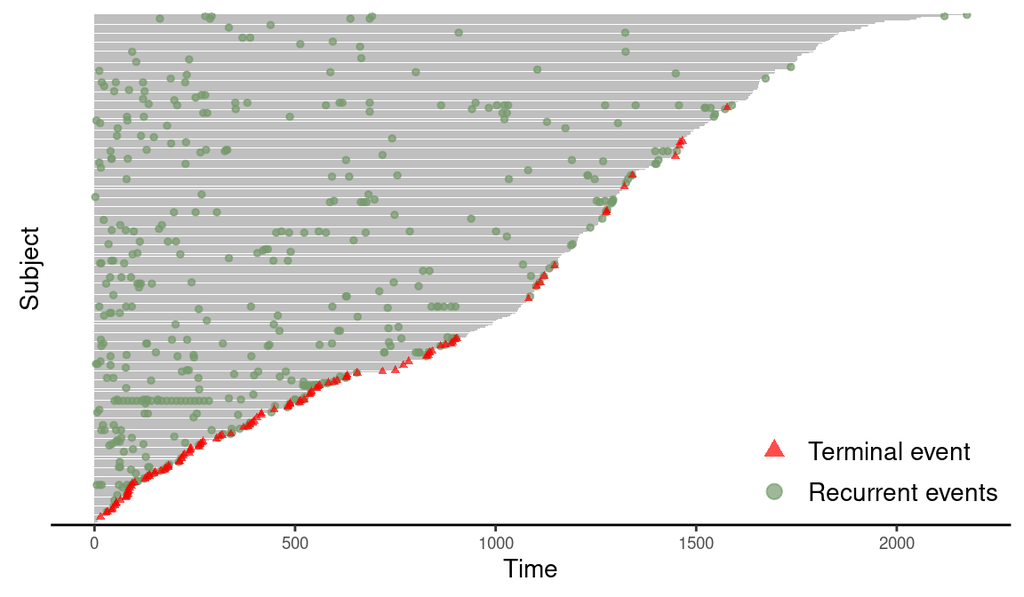

Figure 1: Creating an event plot from a `Recur` object.

```r
> reObj <- with(readmission, Recur(t.stop, id, event, death))
> plot(reObj)
```

The gray horizontal lines represent each subjects’ follow-up times, the green dots marks the recurrent events, and the red triangles marks terminal events. With the default setting, the event plot is arranged so that subjects with longer follow-up times are presented on the top. The `plot()` method returns a `ggplot2` object (Wickham 2009) to allow extensive flexibility and customization. Common graphical options like `xlab`, `ylab`, `main`, and more can be directly passed down to `plot()`.

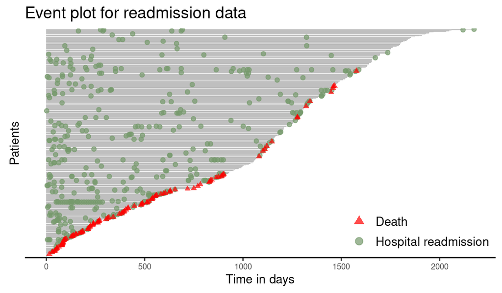

Figure 2: Creating an event plot from a `Recur` object with custom labels.

```r
> plot(reObj, cex = 1.5, xlab = "Time in days", ylab = "Patients",
+      main = "Event plot for readmission data",
+      terminal.name = "Death",
+      recurrent.name = "Hospital readmission")
```

Applying the `plot()` function to `Recur` objects internally calls the `plotEvent()` function, which allows users to configure event plots in a model formula. The synopsis of `plotEvents()` is:

```r
> args(plotEvents)
```

```
function (formula, data, result = c("increasing", "decreasing",
    "asis"), calendarTime = FALSE, control = list(), ...)
NULL
```

The required argument for `plotEvent()` is `formula`. The full list of these parameters with their default values are displayed below.

```r
> args(reReg:::plotEvents.control)
```

```
function (xlab = NULL, ylab = NULL, main = NULL, terminal.name = NULL,
    recurrent.name = NULL, recurrent.type = NULL, legend.position = NULL,
    base_size = 12, cex = NULL, alpha = 0.7, width = NULL, bar.color = NULL,
    recurrent.color = NULL, recurrent.shape = NULL, recurrent.stroke = NULL,
    terminal.color = NULL, terminal.shape = NULL, terminal.stroke = NULL,
    not.terminal.color = NULL, not.terminal.shape = NULL)
NULL
```

The parameters `xlab`, `ylab`, and `main` are adopted from the base `R` `graphics` package for modifying labels to the x-axis, the y-axis, and the main title, respectively. The parameters `terminal.name` and `recurrent.name` are character labels displayed in the legend. The parameter `recurrent.type` specifies the recurrent event types to be displayed in the legend when more than one recurrent event types is specified in the `Recur` object. The parameter `legend.position` is adopted from the % the `legend.position` components of the `ggplot2` theme to control the location of the legend box. The parameters `cex` and `alpha` control the size and the transparency of the symbols on the event plots, respectively. The `base_size` parameter controls the base font size in pts.

Stratifying the event plot could provide new insights into the different covariate effects. For example, an event plot stratified by the binary variable `sex` can be produced with the following code.

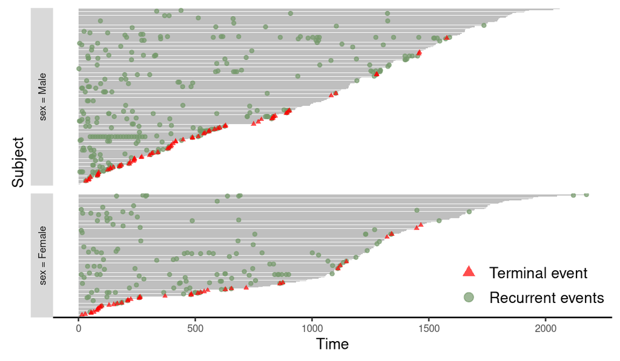

Figure 3: Event plot grouped by `sex`

```r
> plotEvents(Recur(t.stop, id, event, death) ~ sex, data = readmission)
```

Similarly, event plot stratified by `sex` and `chemo` can be produced with the following code. The additional argument `base_size = 5` is included to display the full legend labels.

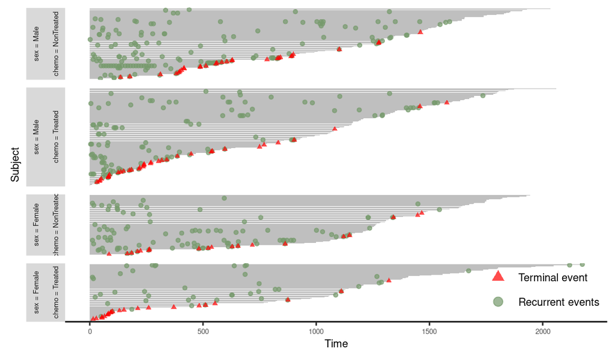

Figure 4: Event plot grouped by `sex` and `chemo`.

```r
> plotEvents(Recur(t.stop, id, event, death) ~ sex + chemo, data = readmission, base_size = 5)
```

The `plotEvents()` can accommodate multiple recurrent types specified via the event argument in the `Recur` object. To illustrate this feature, we perturb the event indicator so that the value of event indicates the index of the different recurrent event. The following command is used to create the stratified event plot with different recurrent event.

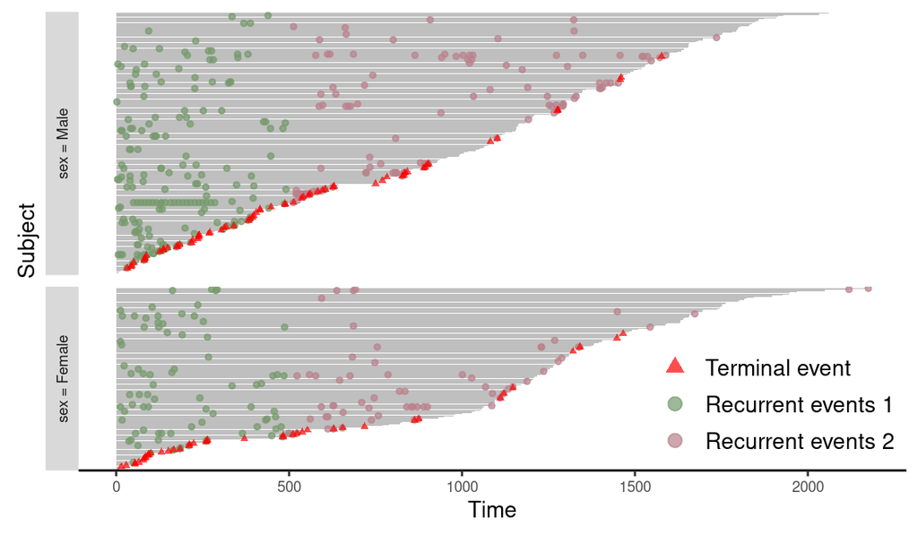

Figure 5: Event plot with multiple events grouped by `sex`.

```r
> readmission$event2 <- with(readmission, ifelse(t.stop > 500 & event > 0, 2, event))
> plotEvents(Recur(t.stop, id, event2, death) ~ sex, data = readmission)
```

The different types of recurrent events are marked in different colors in Figure 5. The `plotEvents()` function can also create event plots in calendar time by setting `calendarTime = TRUE`. For illustration, we create a new simulated data based on `readmission` with time intervals shift proportionally by `chemo`. We further convert the time intervals to a `Date` class. The construction of the new data and the stratified event plot in Figure 6 is included in the following

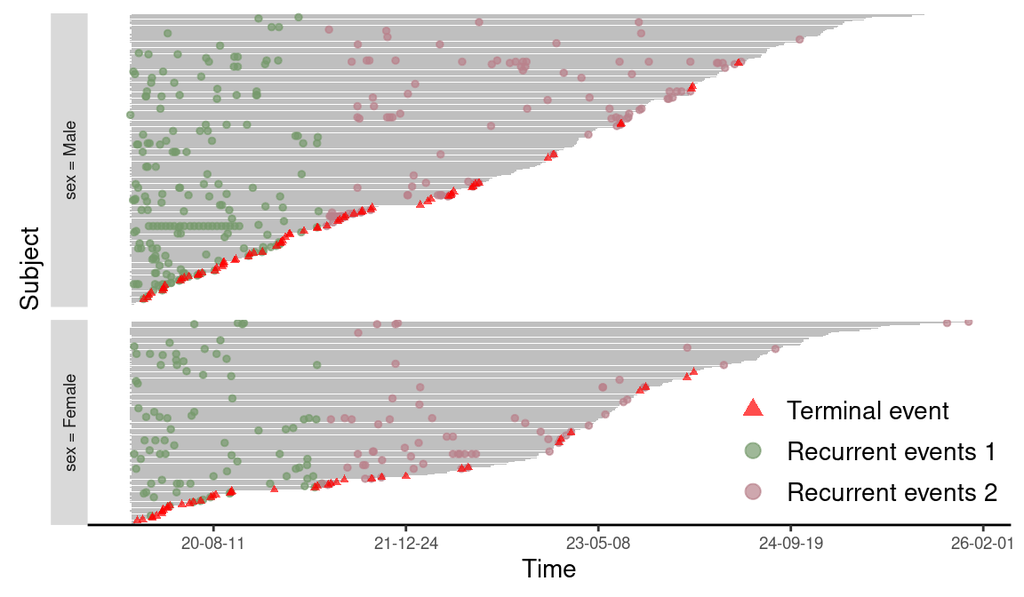

Figure 6: Event plot on calendar time.

```r
> readmission2 <- readmission
> readmission2$t.start <- as.Date(readmission2$t.start + as.numeric(readmission2$chemo) * 5,
+   origin = "20-01-01")
> readmission2$t.stop <- as.Date(readmission2$t.stop + as.numeric(readmission2$chemo) * 5,
+   origin = "20-01-01")
> plotEvents(Recur(t.start %2% t.stop, id, event2, death) ~ sex, data = readmission2,
+            calendarTime = TRUE)
```

In this case, subjects with later censoring times are presented on the top and the date string are printed on the axis label of the event plot.

## Mean cumulative function plots

Let $N(t)$ be the number of recurrent events occurring over the interval $[0, t]$ and $D$ be the failure time of interest subjects to right censoring by $C$. Define the composite censoring time $Y = \min(D, C, \tau)$ and the failure event indicator $\Delta = I\{D\le \min(C, \tau)\}$, where $\tau$ is the maximum follow-up time. We assume the recurrent event process $N(\cdot)$ is observed up to $Y$. Let $X$ be a $p$-dimensional covariate vector. Consider a random sample of $n$ subjects, the observed data are independent and identically distributed (iid) copies of $\{Y_i, \Delta_i, X_i, N_i(t), 0\le t\le Y_i\}$, where the subscript $i$ denotes the index of a subject for $i= 1, \ldots, n$. Let $m_i = N_i(Y_i)$ be the number of recurrent events the $i$th subject experienced before time $Y_i$, then the jump times of $N_i(t)$ give the observed recurrent event times $t_{i1}, \ldots, t_{im_i}$ when $m_i > 0$. Thus, the observed data can also be expressed as iid copies of $\{Y_i, \Delta_i, X_i, m_i, (t_{i1}, \ldots, t_{m_i})\}$.

Under independence censoring, a nonparametric estimate of $\Lambda(t)$ known as the Nelson-Aalen estimator is
$$\widehat\Lambda(t) = \sum_{i =
1}^n\int_0^t\frac{d N_i(u)}{\sum_{j = 1}^nI(Y_i \ge u)},$$
which is also known as the mean cumulative function (MCF). The MCF presents the average number of recurrent events per subject observed by time~$t$ while adjusting for the risk set. In the case when all subjects remain at risk of recurrent events throughout the study, i.e., $n = \sum_{j = 1}^nI(Y_i \ge t)$, the Nelson-Aalen estimator reduces to the cumulative sample mean function introduced in Chapter 1 of Cook and Lawless (2007).

The MCF is useful in describing and comparing the average number of events of an individual and between groups. Thus, it provides additional insights into the longitudinal patterns of the recurrent process. Under the independent censoring assumption, the Nelson-Aalen estimate can be created by applying the generic function `plot()` to the `Recur` object with an additional argument `mcf = TRUE`. The following command plots the Nelson-Aalen estimate in Figure 7. The 95% confidence interval is enabled by additionally setting `mcf.conf.int = TRUE`.

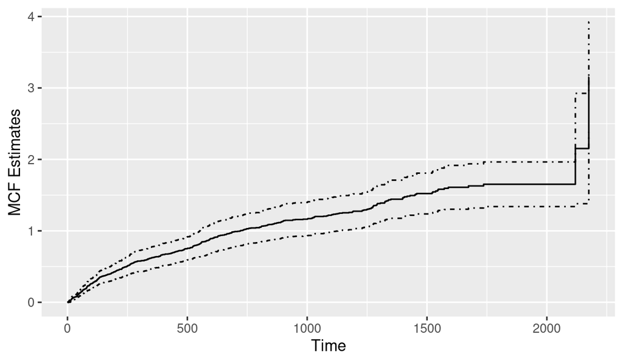

Figure 7: Creating a MCF plot from a `Recur` object.

```r
> plot(reObj, mcf = TRUE, mcf.conf.int = TRUE)
```

To create the cumulative sample mean function, one needs to additionally specify the argument `mcf.adjustRiskset = FALSE`. Plotting the `Recur` object with the argument `mcf = TRUE` internally calls the `mcf()` function from the `reda` package (W. Wang et al. 2021). The `mcf()` function is imported when the `reReg` package is loaded. The usage of the `mcf()` function is similar to that of the `plotEvent()`, where the recurrent event process is specified in a model formula with `Recur` objects as the formula response and the covariates specified in the model formula should be a combination of factor variables. The `mcf()` computes the overall sample MCF when an intercept-only-model is specified. When covariates are specified in the model formula, the sample MCF for each level of the combination of the factor variables will be computed. The following code is used to produce Figure 8, which displays the Nelson-Aalon estimates for `sex = "Female"`and `sex = "Male"`.

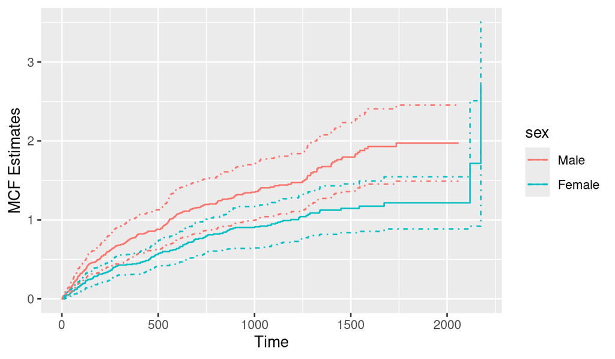

Figure 8: Creating a MCF plot with `mcf()`

```r
> mcf0 <- mcf(Recur(t.start %2% t.stop, id, event, death) ~ sex, data = readmission)
> plot(mcf0, conf.int = TRUE)
```

In the presence of informative censoring, the NPMLE of (M.-C. Wang, Jewell, and Tsai 1986) can be plotted by first fitting an intercept-only model with `reReg()`, then applying the generic function `plot()`. The `Recur` object is used as the formula response. The following code illustrate this feature with output displayed in Figure 9.

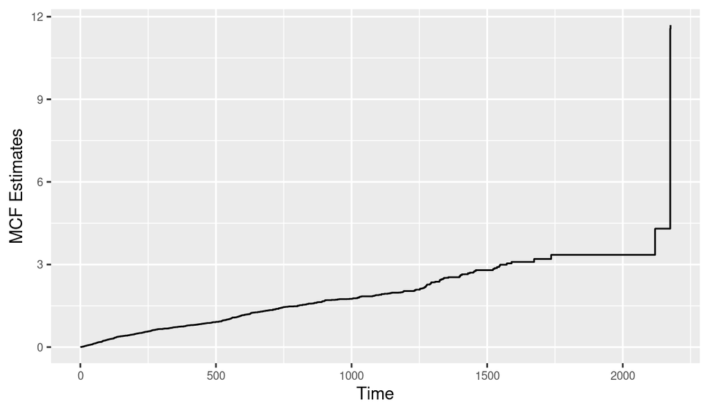

```r
> mcf1 <- reReg(Recur(t.start %2% t.stop, id, event, death) ~ 1, data = readmission)
> plot(mcf1)
```

```r
> args(basebind)
```

```
function (..., legend.title, legend.labels, control = list())
NULL
```

The arguments are

- `...` is a list of `ggplot` objects created by plotting `reReg` objects.
- `legend.title` is an optional character strings to control the legend title in the combined plot.
- `legend.labels` is an optional character strings to control the legend labels in the combined plot.

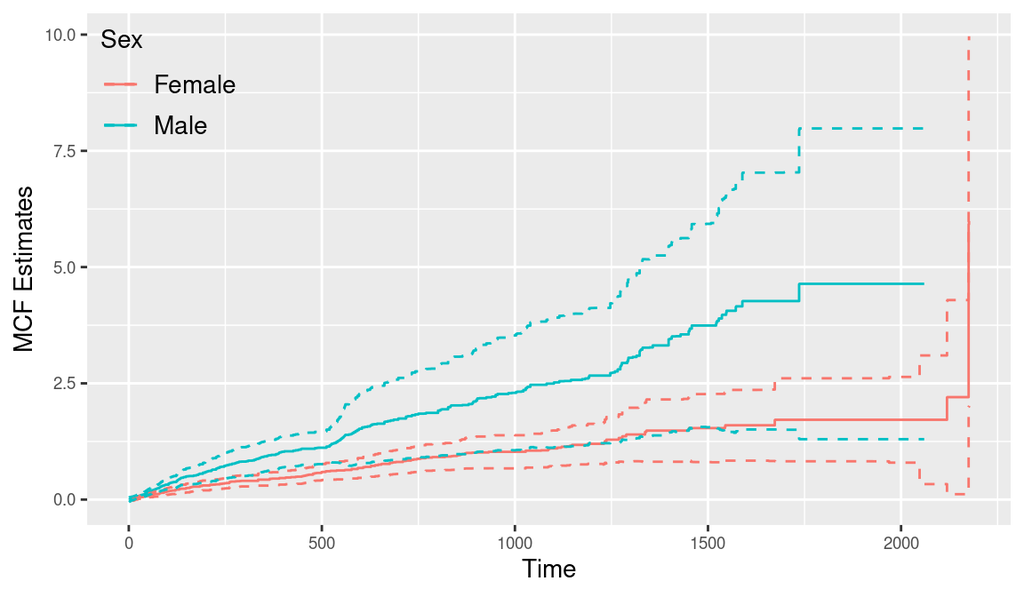

Figure 9: Creating a stratified MCF plot with `reReg()`

```r
> mcf2 <- reReg(Recur(t.start %2% t.stop, id, event, death) ~ 1, subset = sex == "Female", data = readmission, B = 200)
> mcf3 <- update(mcf2, subset = sex == "Male")
> g1 <- plot(mcf2)
> g2 <- plot(mcf3)
> basebind(g1, g2, legend.title = "Sex", legend.labels = c("Female", "Male"))
```

## Linking with `ggplot`

We will take the following `readmission` data for example.

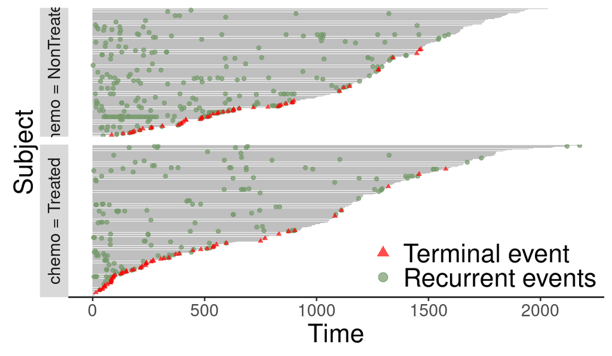

Figure 10: Event plot grouped by `chemo`.

```r
> library(ggplot2)
> (f <- plotEvents(Recur(t.stop, id, event, death) ~ chemo, data = readmission))
```

#### Add axis breaks

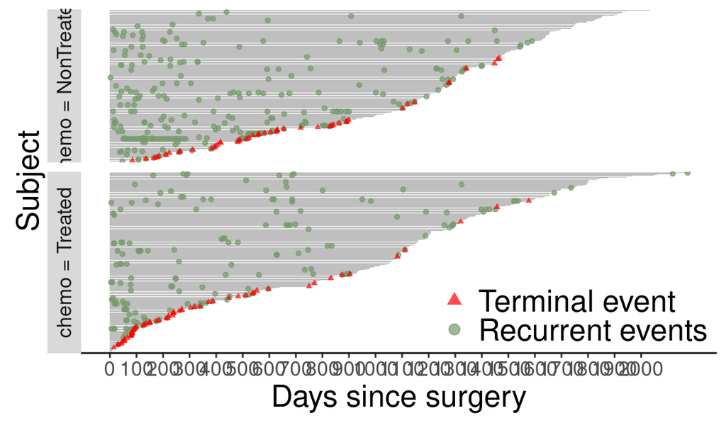

Figure 11: Add axis breaks

```r
> f + scale_y_continuous(breaks = seq(0, 2000, 100)) + ylab("Days since surgery")
```

#### Replace labeling strip in event plot

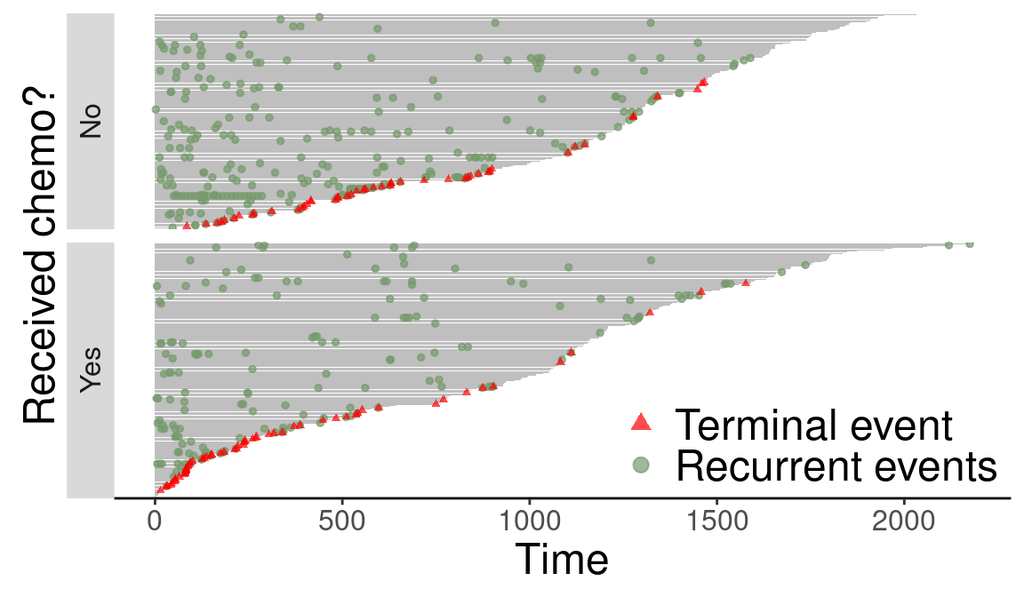

Figure 12: Replace labeling strip in event plot

```r
> labels <- c("chemo = Treated" = "Yes",
+             "chemo = NonTreated" = "No")
> f + facet_grid(chemo ~., scales = "free", space = "free", switch = "both",
+                labeller = labeller(chemo = labels)) +
+   xlab("Received chemo?")
```

#### Customize bar style

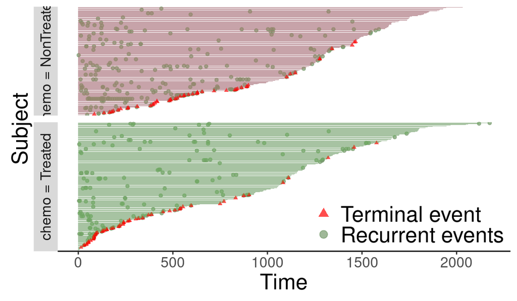

```r
> f + geom_rect(xmin = f$data$id - .45, # bar height
+               xmax = f$data$id + .45, # bar height
+               ymin = 0, ymax = f$data$time2, # bar width
+               fill = 1 + as.numeric(f$data$chemo), # bar color
+               alpha = .25) # transparency
```

## Reference

Cook, Richard J., and Jerald Lawless. 2007. *The Statistical Analysis of Recurrent Events*. New York: Wiley.

González, Juan Ramón, Esteve Fernandez, Víctor Moreno, Josepa Ribes, Mercè Peris, Matilde Navarro, Maria Cambray, and Josep Maria Borrás. 2005. “Sex Differences in Hospital Readmission Among Colorectal Cancer Patients.” *Journal of Epidemiology & Community Health* 59 (6): 506–11.

Rondeau, Virginie, Yassin Mazroui, and Juan Ramń González. 2012. “frailtypack: An R Package for the Analysis of Correlated Survival Data with Frailty Models Using Penalized Likelihood Estimation or Parametrical Estimation.” *Journal of Statistical Software* 47 (4): 1–28.

Wang, Mei-Cheng, Nicholas P. Jewell, and Wei-Yann Tsai. 1986. “Asymptotic Properties of the Product Limit Estimate Under Random Truncation.” *The Annals of Statistics* 14: 1597–1605.

Wang, Wenjie, Haoda Fu, Sy Han Chiou, and Jun Yan. 2021. *reda: Recurrent Event Data Analysis*. https://github.com/wenjie2wang/reda.

Wickham, Hadley. 2009. *ggplot2: Elegant Graphics for Data Analysis*. Springer-Verlag New York. http://ggplot2.org.